# IODS Course - Final Assignment

Tiina Autio

08/03/2017

# Analysis of the library loan data

This data is combination of datasets from Pirkanmaa libraries most loaned 1000 pieces per year from years 2012-2015. To combine all data from all years magazines has been removed from data sets. Original data source (http://www.tampere.fi/tampereen-kaupunki/tietoa-tampereesta/avoin-data.html) and data wrangling file (https://github.com/suprajohde/IODS-final/blob/master/Data/Data%20Wrangling.R) have deeper description of the data.

I wanted to look what are most loaned pieces of the Pirkanmaa librarys per years and how do they vary from year to year. My assumption is that most loaned pieces vary from year to year because each year so many books are being published.

Let’s take a look of the data:

```r
library(dplyr)
library_data <- read.csv("~/Documents/IODS-final/Data/library_data.csv", sep=",", header=TRUE, stringsAsFactors = FALSE)
keep_columns <- c("Hyllypaikka", "Tekijä", "Nimeke", "Lainojen.lkm.", "ISBN.ISSN", "Julkaisuvuosi", "Vuosi")
library_data <- select(library_data, one_of(keep_columns))
colnames(library_data)
```

```
## [1] "Hyllypaikka"   "Tekijä"        "Nimeke"        "Lainojen.lkm."
## [5] "ISBN.ISSN"     "Julkaisuvuosi" "Vuosi"
```

```r
str(library_data)
```

```
## 'data.frame':    3753 obs. of  7 variables:
##  $ Hyllypaikka  : chr  "" "" "" "" ...
##  $ Tekijä       : chr  "" "" "" "" ...
##  $ Nimeke       : chr  "Kirjastokassi." "Kirjastokassi." "Tom & Jerry." "Tom & Jerry." ...
##  $ Lainojen.lkm.: int  478 494 551 1119 567 521 493 515 555 570 ...
##  $ ISBN.ISSN    : chr  "" "" "0357-6493" "0357-6493" ...
##  $ Julkaisuvuosi: int  1999 1999 1980 1980 2011 2012 2010 2009 2008 2009 ...
##  $ Vuosi        : int  2013 2012 2012 2013 2014 2013 2012 2012 2012 2013 ...
```

```r
glimpse(library_data)
```

```
## Observations: 3,753
## Variables: 7
## $ Hyllypaikka   <chr> "", "", "", "", "", " 84.2", ".84.2", ".84.2", "...
## $ Tekijä        <chr> "", "", "", "", "Steel, Danielle.", "James, E. L...
## $ Nimeke        <chr> "Kirjastokassi.", "Kirjastokassi.", "Tom & Jerry...
## $ Lainojen.lkm. <int> 478, 494, 551, 1119, 567, 521, 493, 515, 555, 57...
## $ ISBN.ISSN     <chr> "", "", "0357-6493", "0357-6493", "978-951-0-377...
## $ Julkaisuvuosi <int> 1999, 1999, 1980, 1980, 2011, 2012, 2010, 2009, ...
## $ Vuosi         <int> 2013, 2012, 2012, 2013, 2014, 2013, 2012, 2012, ...
```

Data set has seven variables:  
- shelf location  
- author  
- name - quantity of the loans  
- ISBN.ISSN id  
- publishing year  
- dataset year

This is the summary of the data:

```r
summary(library_data)
```

```
##  Hyllypaikka           Tekijä             Nimeke          Lainojen.lkm.
##  Length:3753        Length:3753        Length:3753        Min.   : 425.0
##  Class :character   Class :character   Class :character   1st Qu.: 514.0
##  Mode  :character   Mode  :character   Mode  :character   Median : 611.0
##                                                           Mean   : 741.6
##                                                           3rd Qu.: 815.0
##                                                           Max.   :3845.0
##   ISBN.ISSN         Julkaisuvuosi      Vuosi
##  Length:3753        Min.   :1974   Min.   :2012
##  Class :character   1st Qu.:2009   1st Qu.:2013
##  Mode  :character   Median :2011   Median :2014
##                     Mean   :2010   Mean   :2014
##                     3rd Qu.:2013   3rd Qu.:2015
##                     Max.   :2015   Max.   :2015
```

Summary of the data shows that there are maximum loan quantity has been 3845 and the lowest loans amount of the data set is 425. Oldest piece is from 1974 and the newest is from year 2015. Median for publishing year is 2011 so all pieces are kind of new.

Most loaned pieces from year 2012:

```r
top_data <- filter(library_data, Vuosi == 2012)

keep_columns <- c("Tekijä", "Nimeke", "Lainojen.lkm.", "Julkaisuvuosi")
top_data <- select(top_data, one_of(keep_columns))

## ordering by loan amount
top_data <- top_data[with(top_data,order(-top_data$Lainojen.lkm.)),]

## only top20
top_data <- top_data[1:20, ]

top_data
```

```
##                  Tekijä                              Nimeke Lainojen.lkm.
## 373     Jokinen, Seppo.                      Hervantalainen          3417
## 570    Nopola, Sinikka. Risto Räppääjä ja viimeinen tötterö          3089
## 571    Nopola, Sinikka.        Risto Räppääjä ja villi kone          2800
## 563    Nopola, Sinikka.  Risto Räppääjä ja kuuluisa Kamilla          2790
## 372     Jokinen, Seppo.                             Ajomies          2714
## 561    Nopola, Sinikka.    Risto Räppääjä ja kauhea makkara          2636
## 26     Nopola, Sinikka.    Risto Räppääjä ja komea Kullervo          2551
## 406       Kettu, Katja.                    Kätilö : romaani          2545
## 572    Nopola, Sinikka.             Risto Räppääjä saa isän          2510
## 554     Nopola, Sinikka           Hetki lyö, Risto Räppääjä          2410
## 566    Nopola, Sinikka.        Risto Räppääjä ja Nuudelipää          2391
## 560    Nopola, Sinikka.     Risto Räppääjä ja Hilpuri Tilli          2363
## 569    Nopola, Sinikka.      Risto Räppääjä ja sitkeä finni          2320
## 308   Havukainen, Aino.        Tatu ja Patu supersankareina          2306
```

[output cut: 27 more lines]

Most of 2012 books are written by same authors. Books of Risto Räppääjä seems to be really interesting for loaners. Reason for this might be that these are children’s books so maybe adults are more interested ro loan these instead of buying.

Most loaned pieces from year 2013:

```r
top_data <- filter(library_data, Vuosi == 2013)

keep_columns <- c("Tekijä", "Nimeke", "Lainojen.lkm.", "Julkaisuvuosi")
top_data <- select(top_data, one_of(keep_columns))

## ordering by loan amount
top_data <- top_data[with(top_data,order(-top_data$Lainojen.lkm.)),]

## only top20
top_data <- top_data[1:20, ]

top_data
```

```
##                   Tekijä                                   Nimeke
## 327      Jokinen, Seppo.                              Vihan sukua
## 549     Nopola, Sinikka.      Risto Räppääjä ja viimeinen tötterö
## 574       Oksanen, Sofi.                  Kun kyyhkyset katosivat
## 542     Nopola, Sinikka.       Risto Räppääjä ja kuuluisa Kamilla
## 325      Jokinen, Seppo.                           Hervantalainen
## 485 Lundberg, Ulla-Lena.                                      Jää
## 550     Nopola, Sinikka.             Risto Räppääjä ja villi kone
## 29      Nopola, Sinikka.         Risto Räppääjä ja komea Kullervo
## 551     Nopola, Sinikka.                  Risto Räppääjä saa isän
## 540     Nopola, Sinikka.         Risto Räppääjä ja kauhea makkara
## 538     Nopola, Sinikka.          Risto Räppääjä ja Hilpuri Tilli
## 257    Havukainen, Aino.             Tatu ja Patu supersankareina
## 531      Nopola, Sinikka                Hetki lyö, Risto Räppääjä
## 544     Nopola, Sinikka.       Risto Räppääjä ja nukkavieru Nelli
```

[output cut: 27 more lines]

Year 2013 Vihan sukua was the most popular book (3415 loans). Most of the list still consists of children’s books.

Most loaned pieces from year 2014:

```r
top_data <- filter(library_data, Vuosi == 2014)

keep_columns <- c("Tekijä", "Nimeke", "Lainojen.lkm.", "Julkaisuvuosi")
top_data <- select(top_data, one_of(keep_columns))

## ordering by loan amount
top_data <- top_data[with(top_data,order(-top_data$Lainojen.lkm.)),]

## only top20
top_data <- top_data[1:20, ]

top_data
```

```
##                            Tekijä
## 202               Jokinen, Seppo.
## 438            Rauhala, Pauliina.
## 370              Nopola, Sinikka.
## 642 Nopola, Sinikka, kirjoittaja.
## 760             Havukainen, Aino.
## 371              Nopola, Sinikka.
## 575               Jokinen, Seppo.
## 628 Nopola, Sinikka, kirjoittaja.
## 759             Havukainen, Aino.
## 32  Nopola, Sinikka, kirjoittaja.
## 359 Nopola, Sinikka, kirjoittaja.
## 358 Nopola, Sinikka, kirjoittaja.
## 758             Havukainen, Aino.
## 709 Nopola, Sinikka, kirjoittaja.
```

[output cut: 48 more lines]

Most loaned pieces from year 2015:

```r
top_data <- filter(library_data, Vuosi == 2015)

keep_columns <- c("Tekijä", "Nimeke", "Lainojen.lkm.", "Julkaisuvuosi")
top_data <- select(top_data, one_of(keep_columns))

## ordering by loan amount
top_data <- top_data[with(top_data,order(-top_data$Lainojen.lkm.)),]

## only top20
top_data <- top_data[1:20, ]

top_data
```

```
##                            Tekijä
## 608  Jokinen, Seppo, kirjoittaja.
## 395              Nopola, Sinikka.
## 784             Havukainen, Aino.
## 672 Nopola, Sinikka, kirjoittaja.
## 204               Jokinen, Seppo.
## 396              Nopola, Sinikka.
## 783             Havukainen, Aino.
## 659              Nopola, Sinikka.
## 658 Nopola, Sinikka, kirjoittaja.
## 374 Nopola, Sinikka, kirjoittaja.
## 719 Nopola, Sinikka, kirjoittaja.
## 782             Havukainen, Aino.
## 379 Nopola, Sinikka, kirjoittaja.
## 781             Havukainen, Aino.
```

[output cut: 48 more lines]

```r
library_data %>% group_by(Nimeke, Tekijä, Julkaisuvuosi, ISBN.ISSN) %>% summarize(sum=n()) -> sums
sums <- sums[with(sums,order(-sums$sum)),]

sums[1:20, ]
```

```
## Source: local data frame [20 x 5]
## Groups: Nimeke, Tekijä, Julkaisuvuosi [20]
##
##                                                                     Nimeke
##                                                                      <chr>
## 1                                                          Aamun hämärissä
## 2  Aarresaari : kunnasmainen tulkinta Robert Louis Stevensonin klassikosta
## 3                                                                     Aave
## 4                                                   Aino ja Pakkasen Poika
## 5                                                   Ainon äiti on vihainen
## 6                                                              Äitienpäivä
## 7                                                                  Ajomies
## 8                                                      Älä pelkää, Sinttu!
## 9                                                     Alakuloinen romanssi
## 10                                                        Aprillia, Sinttu
## 11                                                          Avaimet onneen
## 12                                                         Dinosauruspäivä
## 13                                                  Ella : varokaa lapsia!
## 14                                                          Ella aalloilla
## 15                                                         Ella ja Äf Yksi
## 16                                                      Ella ja jättipotti
## 17                                            Ella ja kadonnut karttakeppi
## 18                                           Ella ja kaverit juhlatuulella
## 19                                                            Ella ja Pate
## 20                                                        Ella ja Paterock
## # ... with 4 more variables: Tekijä <chr>, Julkaisuvuosi <int>,
## #   ISBN.ISSN <chr>, sum <int>
```

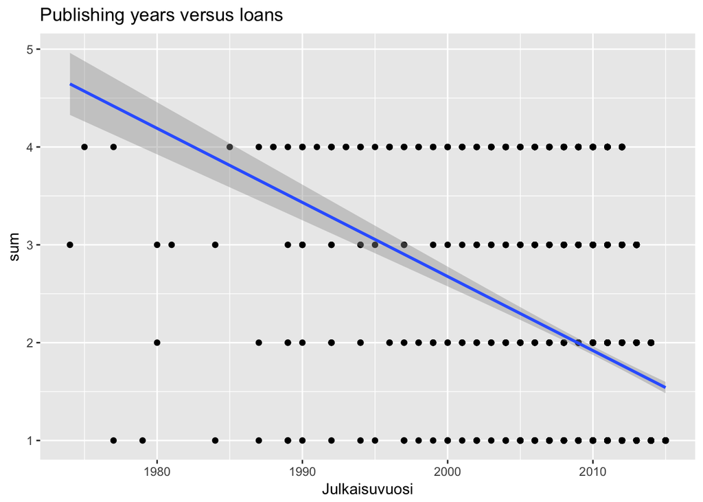

```r
library(ggplot2)
qplot(Julkaisuvuosi, sum, data = sums) + geom_smooth(method = "lm") +ggtitle("Publishing years versus loans")
```

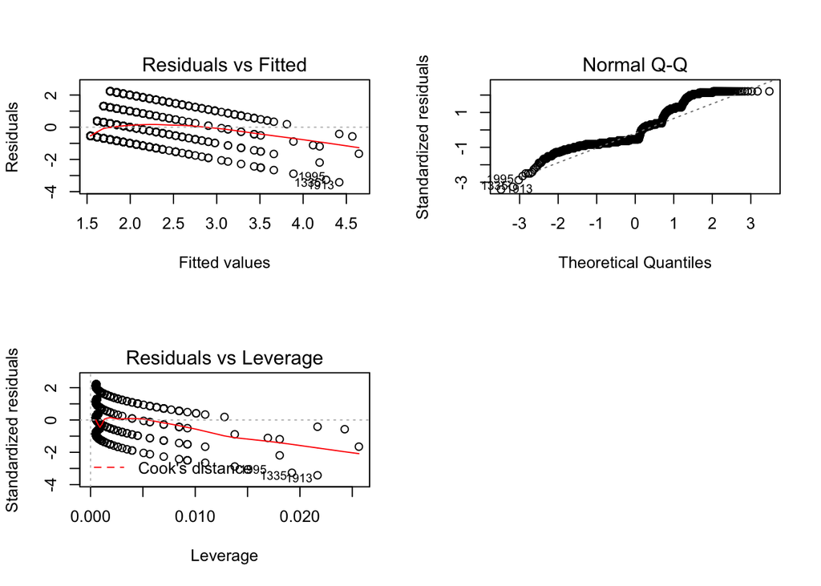

```r
my_model2 <- lm(sum ~ Julkaisuvuosi, data = sums)
par(mfrow = c(2,2))
plot(my_model2, c(1, 2, 5))
```

Final words. It has been nice to learn R and it seems to be powerful tool for data analysis especially with Markdown syntax. Still a lot more needs to be learn until I’ll remember all handy librarys and funtions. I also noticed that my data set wasn’t very good for this kind of analysis (only calculation was number of loans).

Data wrangling took a lot of time (because I have to learn how to split columns etc.). At first I thought that just combining library data from four years should be pretty easy but later I noticed that there are some challenges as well. Because loan counting for individual magazine numbers have been started from 2014, first two years had too high loan amount per magazine. Thus I had to remove them from the data sets. One challenge also was that R has many ways to end up to same result so sometimes it was hard to know which function to pick.